# Association rules and scaling

Przemyslaw Biecek

Data Mining - Advances

# Association rules

```r
library(dplyr)
```

## Introduction

Let Z be the set of items and X, Y be a subsets of Z, called itemsets.

A rule has form X -> Y.

We will use three measures that summarise a rule or it’s itemsets.

`Support` of an itemset X is the percentage of transactions covered by X. If n is the number of all transactions and n_X transactions in X then

`supp(X) = n_X/n`

`Confidence` of a rule is the percentage of transactions with Y in all transactions covred by X.

`conf(X -> Y)` = `supp(X+Y) / supp(X)`

`Lift` is a measure of deviation from statistical independence. It takes value 1 if X and Y are independent and values greater than 1 for positive dependence.

`lift(X -> Y)` = `conf(X -> Y) / supp(Y)` = `supp(X+Y)/(supp(X) supp(Y))`

A good rule should has high support and high confidence. Usually we apply some filters for `supp(X+Y)` and `cond(X -> Y)`.

The procedure how to find frequent itemsets and good rules is non trivial. See for example a very good description http://michael.hahsler.net/research/arules_RUG_2015/demo/ and http://michael.hahsler.net/research/arules_RUG_2015/talk/arules_RUG2015.pdf

## Basic Example

We will use `apriori` function from `arules` package to find rules based on `Groceries` dataset.

Let’s see how the data is stored (sparse matrix).

```r
library("arules")
data("Groceries")
Groceries
```

```
## transactions in sparse format with
##  9835 transactions (rows) and
##  169 items (columns)
```

```r
head(Groceries@itemInfo)
```

```
##              labels  level2           level1
## 1       frankfurter sausage meet and sausage
## 2           sausage sausage meet and sausage
## 3        liver loaf sausage meet and sausage
## 4               ham sausage meet and sausage
## 5              meat sausage meet and sausage
## 6 finished products sausage meet and sausage
```

```r
head(Groceries@data,5)
```

```
## 5 x 9835 sparse Matrix of class "ngCMatrix"
##
## [1,] . . . . . . . . . . . . . | . . . . . . . . . . . . . . . . . . . . .
## [2,] . . . . . . . . . . . . . . . . . . . . . . . . . . . | . . . . . . .
## [3,] . . . . . . . . . . . . . . . . . . . . . . . . . . . . . . . . . . .
## [4,] . . . . . . . . . . . . . . . . . . . . . . . . . . . . . . . . . . .
## [5,] . . . . . . . . . . . . . . . . . . . . . . . . . . . . . . . . . . .
##
## [1,] . . . . . . . . . . . . . . . . . . . . . . . . . . . . | . . . . . .
## [2,] . . . . . | . . . . . . . . . | . . . . . . . . . . | | . . . . . | .
## [3,] . . . . . . . . . . . . . . . . . . . . . . . . . . . . . . . . . . .
## [4,] . . . . . . . . . . . . . . . . . | . . . . . | . . . . . . . . . . .
## [5,] . . . . . . . . . . . . . . . . . . . . . . . . . . . . . . . . . . .
##
## [1,] . . | . . . . . . . . . . . . . . . . . . . . . . . . . . . . . | . .
```

[output cut: 1672 more lines]

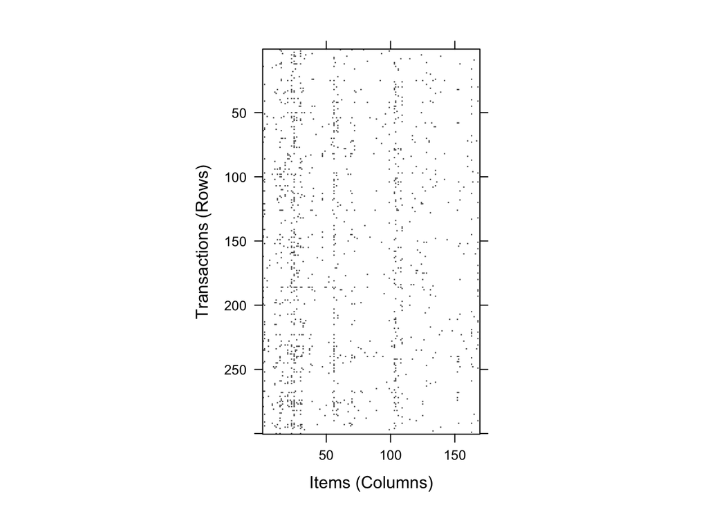

```r
image(head(Groceries,300))
```

Now we can extract some rules.

```r
rules <- apriori(Groceries, parameter = list(support = .001))
```

```
## Apriori
##
## Parameter specification:
##  confidence minval smax arem  aval originalSupport support minlen maxlen
##         0.8    0.1    1 none FALSE            TRUE   0.001      1     10
##  target   ext
##   rules FALSE
##
## Algorithmic control:
##  filter tree heap memopt load sort verbose
##     0.1 TRUE TRUE  FALSE TRUE    2    TRUE
##
## Absolute minimum support count: 9
##
## set item appearances ...[0 item(s)] done [0.00s].
## set transactions ...[169 item(s), 9835 transaction(s)] done [0.00s].
## sorting and recoding items ... [157 item(s)] done [0.00s].
## creating transaction tree ... done [0.00s].
## checking subsets of size 1 2 3 4 5 6 done [0.01s].
## writing ... [410 rule(s)] done [0.00s].
## creating S4 object  ... done [0.00s].
```

```r
rules
```

```
## set of 410 rules
```

```r
inspect(head(sort(rules, by = "lift"), 3))
```

```
##   lhs                        rhs                   support confidence     lift
## 1 {liquor,
##    red/blush wine}        => {bottled beer}    0.001931876  0.9047619 11.23527
## 2 {citrus fruit,
##    other vegetables,
##    soda,
##    fruit/vegetable juice} => {root vegetables} 0.001016777  0.9090909  8.34040
## 3 {tropical fruit,
##    other vegetables,
##    whole milk,
##    yogurt,
##    oil}                   => {root vegetables} 0.001016777  0.9090909  8.34040
```

Your turn: change parameters to have rules with confidence > 0.9.

## A bit more complicated example

Let’s try to apply this approach to our dataset.

We need to convert data about visited stations into the matrix with transactions.

```r
load("/Users/pbiecek/Dropbox/CNK/verySmallLogs.rda")

trans <- verySmallLogs %>%
  group_by(visitor) %>%
  summarise(path = paste(sort(unique(substr(grep(station, pattern="^[^1]", value=TRUE), 1, 5))), collapse=";"))

save(trans, file="trans.rda")
head(trans,10)
```

```
## Source: local data frame [10 x 2]
##
##    visitor                                                        path
##      (chr)                                                       (chr)
## 1       -1 cnk04;cnk05;cnk10;cnk18;cnk19;cnk20;cnk38;cnk56;cnk61;cnk66
## 2   795453                                                       cnk61
## 3   795455                                                 cnk10;cnk66
## 4   795467                                                       cnk10
## 5   795476                                           cnk18;cnk38;cnk61
## 6   795477                                                       cnk56
## 7   795486                                           cnk56;cnk61;cnk66
## 8   795488                               cnk05;cnk10;cnk56;cnk61;cnk66
## 9   795492                                                 cnk56;cnk61
## 10  795495                                           cnk10;cnk20;cnk56
```

For each visitor we have stations that have been visited. Let’s convert this data into a list of vectors. This format is supported by the `apriori` function.

```r
listTrans <- strsplit(as.character(as.data.frame(trans)[,2]), split=";")
names(listTrans) <- paste0("U",as.data.frame(trans)[,1])
head(listTrans)
```

```
## $`U-1`
##  [1] "cnk04" "cnk05" "cnk10" "cnk18" "cnk19" "cnk20" "cnk38" "cnk56"
##  [9] "cnk61" "cnk66"
##
## $U795453
## [1] "cnk61"
##
## $U795455
## [1] "cnk10" "cnk66"
##
## $U795467
## [1] "cnk10"
##
## $U795476
## [1] "cnk18" "cnk38" "cnk61"
##
## $U795477
## [1] "cnk56"
```

```r
# convert into transactions
trans1 <- as(listTrans, "transactions")
summary(trans1)
```

```
## transactions as itemMatrix in sparse format with
##  62635 rows (elements/itemsets/transactions) and
##  10 columns (items) and a density of 0.2211814
##
## most frequent items:
##   cnk19   cnk18   cnk10   cnk05   cnk20 (Other)
##   28720   18846   16709   14918   14826   44518
##
## element (itemset/transaction) length distribution:
## sizes
##     1     2     3     4     5     6     7     8     9    10
## 25247 16611 10354  5691  2891  1253   448   128    11     1
##
##    Min. 1st Qu.  Median    Mean 3rd Qu.    Max.
##   1.000   1.000   2.000   2.212   3.000  10.000
##
## includes extended item information - examples:
##   labels
## 1  cnk04
## 2  cnk05
## 3  cnk10
##
## includes extended transaction information - examples:
##   transactionID
## 1           U-1
## 2       U795453
## 3       U795455
```

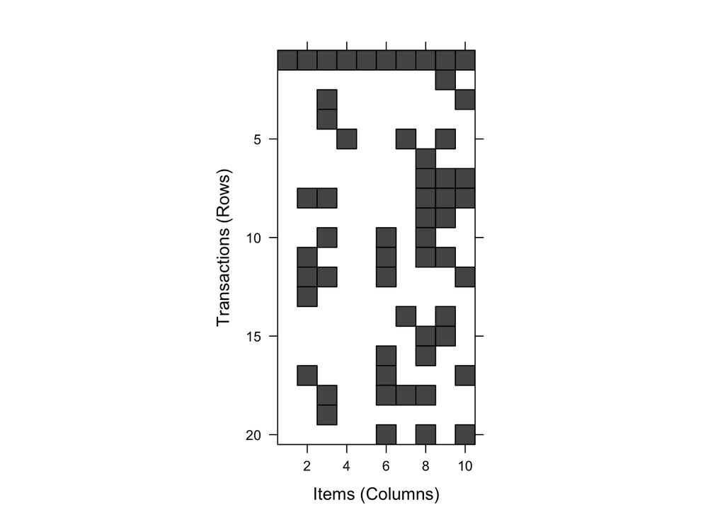

```r
image(head(trans1,20))
```

Now we are ready to mine rules in such dataset. In order to speed up the process we can add additional restrictions for maximum size of itemsets.

```r
rules <- apriori(trans1, parameter = list(support = .001, maxlen=10, confidence=0.7))
```

```
## Apriori
##
## Parameter specification:
##  confidence minval smax arem  aval originalSupport support minlen maxlen
##         0.7    0.1    1 none FALSE            TRUE   0.001      1     10
##  target   ext
##   rules FALSE
##
## Algorithmic control:
##  filter tree heap memopt load sort verbose
##     0.1 TRUE TRUE  FALSE TRUE    2    TRUE
##
## Absolute minimum support count: 62
##
## set item appearances ...[0 item(s)] done [0.00s].
## set transactions ...[10 item(s), 62635 transaction(s)] done [0.01s].
## sorting and recoding items ... [9 item(s)] done [0.00s].
## creating transaction tree ... done [0.02s].
## checking subsets of size 1 2 3 4 5 6 7 8 done [0.00s].
## writing ... [72 rule(s)] done [0.00s].
## creating S4 object  ... done [0.01s].
```

```r
rules
```

```
## set of 72 rules
```

```r
inspect(head(sort(rules, by = "lift"), 10))
```

```
##    lhs                                      rhs     support     confidence
## 58 {cnk10,cnk18,cnk19,cnk38,cnk61,cnk66} => {cnk05} 0.001149517 0.7826087
## 3  {cnk10,cnk38,cnk56,cnk61,cnk66}       => {cnk20} 0.001005827 0.7777778
## 7  {cnk10,cnk38,cnk56,cnk61,cnk66}       => {cnk05} 0.001005827 0.7777778
## 56 {cnk10,cnk18,cnk19,cnk20,cnk38,cnk61} => {cnk05} 0.001149517 0.7741935
## 72 {cnk05,cnk10,cnk18,cnk19,cnk20,cnk61} => {cnk66} 0.002873793 0.7468880
## 45 {cnk05,cnk10,cnk19,cnk20,cnk38,cnk61} => {cnk66} 0.001165483 0.7448980
## 49 {cnk05,cnk18,cnk19,cnk20,cnk38,cnk61} => {cnk66} 0.001117586 0.7446809
## 66 {cnk05,cnk18,cnk19,cnk20,cnk56,cnk61} => {cnk66} 0.001069689 0.7444444
## 40 {cnk10,cnk18,cnk20,cnk38,cnk61,cnk66} => {cnk05} 0.001644448 0.7629630
## 5  {cnk10,cnk20,cnk38,cnk56,cnk61}       => {cnk05} 0.001133552 0.7553191
##    lift
## 58 3.285876
## 3  3.285857
## 7  3.265593
## 56 3.250544
## 72 3.231871
## 45 3.223260
## 49 3.222320
## 66 3.221297
## 40 3.203391
## 5  3.171297
```

```r
inspect(head(sort(rules, by = "support"), 10))
```

```
##    lhs                                      rhs     support     confidence
## 34 {cnk05,cnk18,cnk20,cnk61,cnk66}       => {cnk10} 0.005907240 0.7283465
## 35 {cnk10,cnk18,cnk20,cnk61,cnk66}       => {cnk05} 0.005907240 0.7115385
## 36 {cnk05,cnk10,cnk18,cnk20,cnk61}       => {cnk66} 0.005907240 0.7269155
## 37 {cnk05,cnk18,cnk19,cnk20,cnk61}       => {cnk66} 0.004103137 0.7041096
## 1  {cnk05,cnk20,cnk38,cnk61}             => {cnk10} 0.003368724 0.7009967
## 26 {cnk10,cnk18,cnk20,cnk38,cnk66}       => {cnk05} 0.003240999 0.7275986
## 69 {cnk05,cnk10,cnk19,cnk20,cnk61,cnk66} => {cnk18} 0.002873793 0.7003891
## 70 {cnk05,cnk18,cnk19,cnk20,cnk61,cnk66} => {cnk10} 0.002873793 0.7003891
## 71 {cnk10,cnk18,cnk19,cnk20,cnk61,cnk66} => {cnk05} 0.002873793 0.7317073
## 72 {cnk05,cnk10,cnk18,cnk19,cnk20,cnk61} => {cnk66} 0.002873793 0.7468880
##    lift
## 34 2.730264
## 35 2.987479
## 36 3.145448
## 37 3.046764
## 1  2.627741
## 26 3.054909
## 69 2.327755
## 70 2.625464
## 71 3.072160
## 72 3.231871
```

Our rules have very small support.

We can train them on much larger dataset to get larger support.

# Multidimensional scaling

Working with high dimensional data we are unable to properly visualise the dataset or sometimes our methods are not capable to deal with too high dimension.

So we may use some techniques to reduce the dimension in our data

## Principal Components Analysis

### Introduction

The most basic technique is PCA. It’ goal is to find another parameterisation of the whole space in which variance in the data is highest in consecutive dimensions. Then usually only first two or three dimensions in the new dataset is left.

Important: New variables are orthogonal and are linear transformations of the original variables.

In R it’s implemented in two function `princomp` (uses the eigen value decomposition) and `prcomp` (uses SVD decomposition).

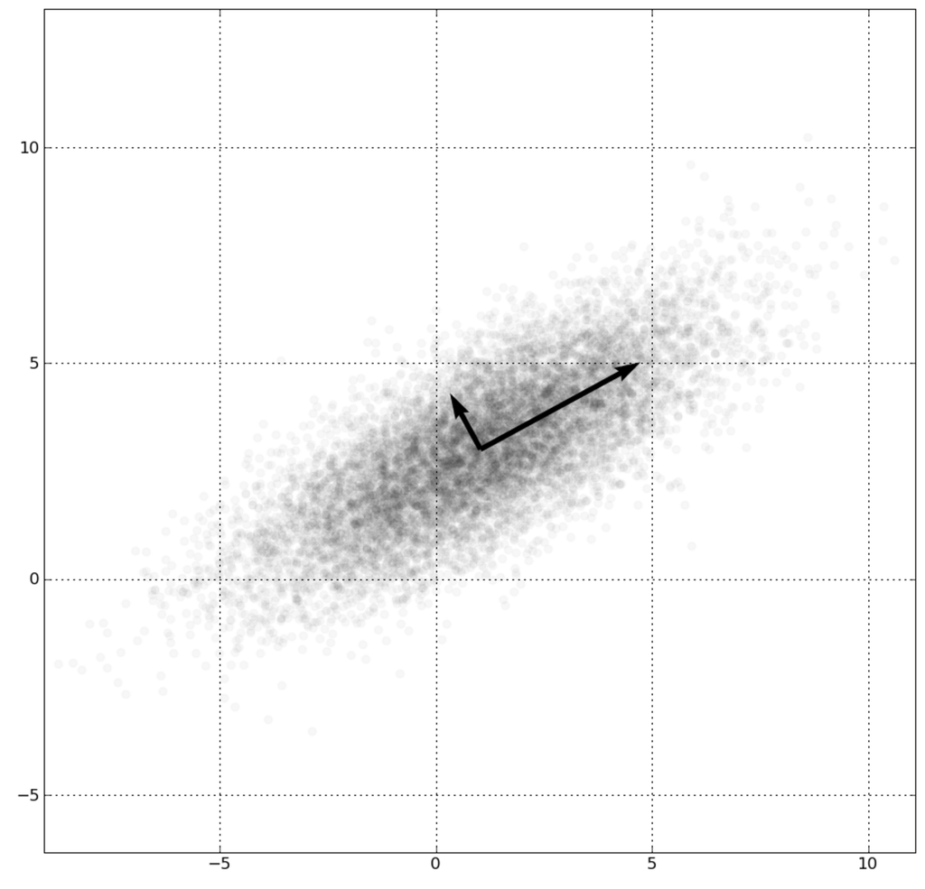

### Basic example

Let us start with an example

```r
head(USArrests)
```

```
##            Murder Assault UrbanPop Rape
## Alabama      13.2     236       58 21.2
## Alaska       10.0     263       48 44.5
## Arizona       8.1     294       80 31.0
## Arkansas      8.8     190       50 19.5
## California    9.0     276       91 40.6
## Colorado      7.9     204       78 38.7
```

```r
pca <- princomp(~ Murder + Assault + UrbanPop,
                  data = USArrests, cor = TRUE)
summary(pca)
```

```
## Importance of components:
##                          Comp.1    Comp.2     Comp.3
## Standard deviation     1.365655 0.9795415 0.41890995
## Proportion of Variance 0.621671 0.3198339 0.05849518
## Cumulative Proportion  0.621671 0.9415048 1.00000000
```

```r
pca$scores[1:5, ]
```

```
##                 Comp.1     Comp.2     Comp.3
## Alabama    -1.25080553  0.9341207  0.2015063
## Alaska     -0.80065917  1.3941923 -0.6532667
## Arizona    -1.35427654 -0.8368948 -0.8488785
## Arkansas   -0.03474106  1.1176667 -0.1876530
## California -1.54281817 -1.5178447 -0.4231652
```

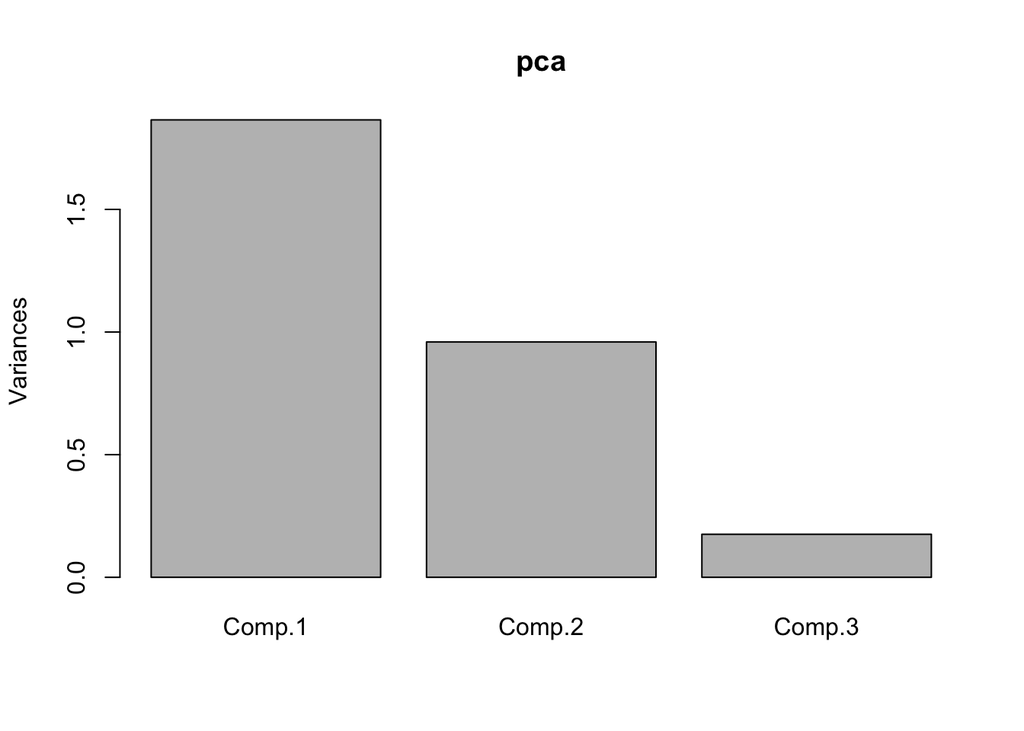

```r
plot(pca)
```

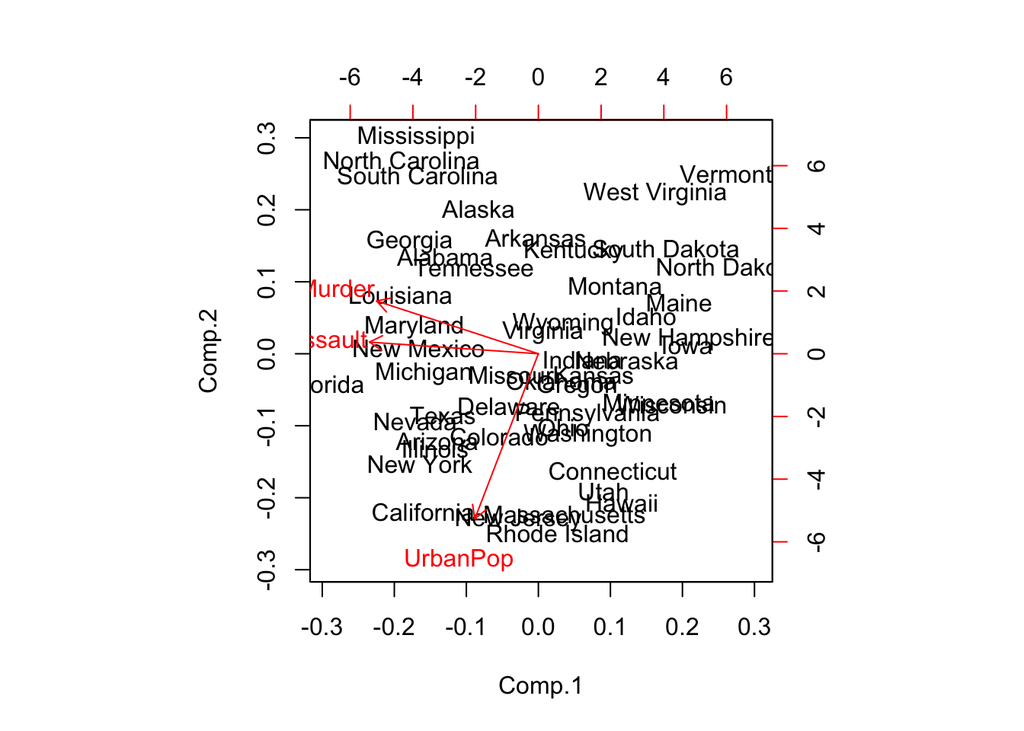

```r
biplot(pca)
```

```r
pca$loadings
```

```
##
## Loadings:
##          Comp.1 Comp.2 Comp.3
## Murder   -0.667  0.303  0.680
## Assault  -0.697        -0.714
## UrbanPop -0.262 -0.950  0.167
##
##                Comp.1 Comp.2 Comp.3
## SS loadings     1.000  1.000  1.000
## Proportion Var  0.333  0.333  0.333
## Cumulative Var  0.333  0.667  1.000
```

### A bit more complicated

How we can apply this to larger dataset?

```r
library(tidyr)
nvisits <- verySmallLogs %>%
  group_by(visitor, station) %>%
  summarise(count = n()) %>%
  spread(station, count)

head(nvisits)
```

```
## Source: local data frame [6 x 11]
##
##   visitor  cnk04 cnk05 cnk10 cnk18 cnk19a cnk20 cnk38 cnk56 cnk61 cnk66
##     (chr)  (int) (int) (int) (int)  (int) (int) (int) (int) (int) (int)
## 1      -1 602658     4     4     4     15     4     4     8     4     4
## 2  795453     NA    NA    NA    NA     NA    NA    NA    NA    10    NA
## 3  795455     NA    NA    24    NA     NA    NA    NA    NA    NA    34
## 4  795467     NA    NA     8    NA     NA    NA    NA    NA    NA    NA
## 5  795476     NA    NA    NA    16     NA    NA    42    NA    10    NA
## 6  795477     NA    NA    NA    NA     NA    NA    NA    74    NA    NA
```

```r
nvisits[is.na(nvisits)] <- 0
head(nvisits)
```

```
## Source: local data frame [6 x 11]
##
##   visitor  cnk04 cnk05 cnk10 cnk18 cnk19a cnk20 cnk38 cnk56 cnk61 cnk66
##     (chr)  (dbl) (dbl) (dbl) (dbl)  (dbl) (dbl) (dbl) (dbl) (dbl) (dbl)
## 1      -1 602658     4     4     4     15     4     4     8     4     4
## 2  795453      0     0     0     0      0     0     0     0    10     0
## 3  795455      0     0    24     0      0     0     0     0     0    34
## 4  795467      0     0     8     0      0     0     0     0     0     0
## 5  795476      0     0     0    16      0     0    42     0    10     0
## 6  795477      0     0     0     0      0     0     0    74     0     0
```

```r
pcaL <- princomp(nvisits[-1,-1])
summary(pcaL)
```

```
## Importance of components:
##                            Comp.1     Comp.2     Comp.3      Comp.4
## Standard deviation     23.6406832 18.7658023 14.3397815 13.46374761
## Proportion of Variance  0.2956198  0.1862721  0.1087673  0.09588383
## Cumulative Proportion   0.2956198  0.4818919  0.5906592  0.68654304
##                             Comp.5      Comp.6      Comp.7     Comp.8
## Standard deviation     13.15938249 12.34363194 12.20777548 9.67651489
## Proportion of Variance  0.09159768  0.08059338  0.07882909 0.04952807
## Cumulative Proportion   0.77814073  0.85873411  0.93756321 0.98709128
##                            Comp.9 Comp.10
## Standard deviation     4.94009080       0
## Proportion of Variance 0.01290872       0
## Cumulative Proportion  1.00000000       1
```

```r
pcaL$scores[1:5,]
```

```
##          Comp.1     Comp.2     Comp.3     Comp.4     Comp.5    Comp.6
## [1,]   6.383313 -14.187404   4.027057  -1.926886 -0.4042921  7.380955
## [2,]   7.839091   8.860228 -20.753939 -11.773066  9.0759704 -0.639249
## [3,]   6.774600 -11.455649   3.933666  -3.244293  6.8738923 -2.133569
## [4,]   6.600448  -7.599338  -4.583416  38.982992  1.8945644  6.736431
## [5,] -67.315517 -11.788352   4.442807  -2.721341  0.1198146 -3.859134
##           Comp.7     Comp.8   Comp.9 Comp.10
## [1,]  0.08033818   4.446721 4.634007       0
## [2,] 20.75650201   6.820344 4.081287       0
## [3,]  3.40082580   4.108502 4.589680       0
## [4,]  2.21956047 -10.238063 2.939142       0
## [5,]  3.09870881   3.048126 4.141955       0
```

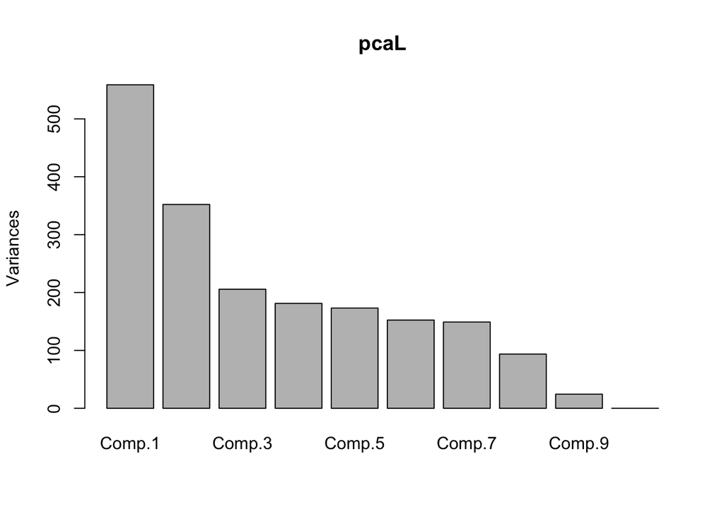

```r
plot(pcaL)
```

```r
pcaL$loadings
```

```
##
## Loadings:
##        Comp.1 Comp.2 Comp.3 Comp.4 Comp.5 Comp.6 Comp.7 Comp.8 Comp.9
## cnk04
## cnk05          0.747  0.592        -0.298
## cnk10          0.435 -0.105 -0.136  0.879
## cnk18                                                   -0.990
## cnk19a                                                         -0.998
## cnk20          0.260 -0.371        -0.109 -0.291 -0.830
## cnk38          0.126 -0.176  0.971
## cnk56  -0.999
## cnk61                                      0.954 -0.270
## cnk66          0.393 -0.677 -0.187 -0.349         0.474
##        Comp.10
## cnk04   1.000
## cnk05
## cnk10
## cnk18
## cnk19a
## cnk20
## cnk38
## cnk56
## cnk61
## cnk66
##
##                Comp.1 Comp.2 Comp.3 Comp.4 Comp.5 Comp.6 Comp.7 Comp.8
## SS loadings       1.0    1.0    1.0    1.0    1.0    1.0    1.0    1.0
## Proportion Var    0.1    0.1    0.1    0.1    0.1    0.1    0.1    0.1
## Cumulative Var    0.1    0.2    0.3    0.4    0.5    0.6    0.7    0.8
##                Comp.9 Comp.10
## SS loadings       1.0     1.0
## Proportion Var    0.1     0.1
## Cumulative Var    0.9     1.0
```

## Isometric scaling

PCA is very popular, but it is not the only method that can be used for dimension reduction. Other, very popular one, is the Kruskal’s non-metric multidimensional scaling.

There are few interesting and important differences.

- As an input we will use distance matrix not original data. Thus we can use this method even if we are working with non numerical data (e.g. documents). All we need is to define dissimilarity
- Solution is calculated through numerical optimization, sometimes it can be unstable.
- The new coordinated are derived in such a way, that the overall stress is minimized, where stress is defined as the sum of squared differences between the original and transformed dataset (but other definitions of stress are also valid).

### Basic example

Let us start with an example

Sammon scaling - the sum of squared differences between the initial distances and obtained ones, weighted by the distances

```r
library(MASS)
head(USArrests)
```

```
##            Murder Assault UrbanPop Rape
## Alabama      13.2     236       58 21.2
## Alaska       10.0     263       48 44.5
## Arizona       8.1     294       80 31.0
## Arkansas      8.8     190       50 19.5
## California    9.0     276       91 40.6
## Colorado      7.9     204       78 38.7
```

```r
distances <- dist(scale(USArrests))

mds1 <- sammon(distances, k=2)
```

```
## Initial stress        : 0.02606
## stress after  10 iters: 0.01805, magic = 0.092
## stress after  20 iters: 0.01517, magic = 0.213
## stress after  30 iters: 0.01374, magic = 0.500
## stress after  40 iters: 0.01371, magic = 0.500
```

```r
str(mds1)
```

```
## List of 3
##  $ points: num [1:50, 1:2] -0.897 -2.886 -1.963 0.164 -2.559 ...
##   ..- attr(*, "dimnames")=List of 2
##   .. ..$ : chr [1:50] "Alabama" "Alaska" "Arizona" "Arkansas" ...
##   .. ..$ : NULL
##  $ stress: num 0.0137
##  $ call  : language sammon(d = distances, k = 2)
```

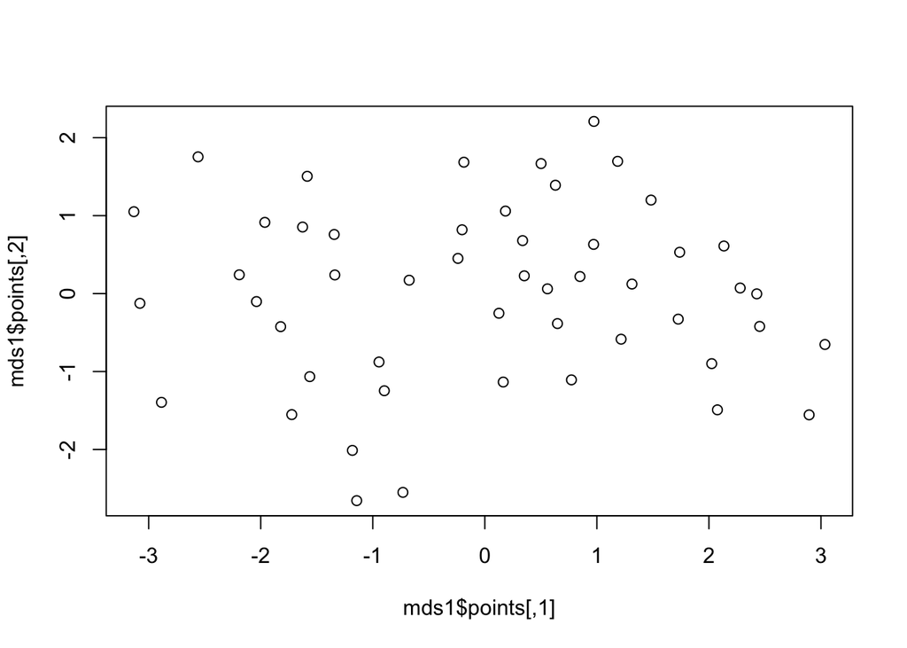

```r
plot(mds1$points)
```

We can then see some diagnostics

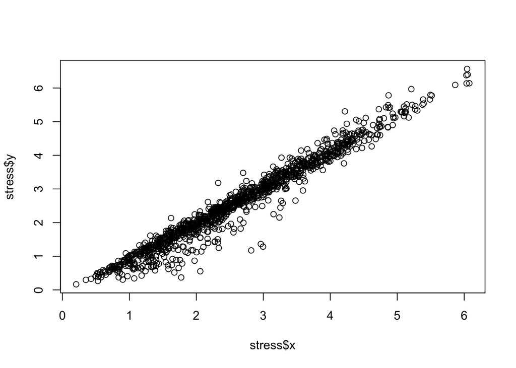

```r
stress <- Shepard(distances, mds1$points)
plot(stress)
```

Kruskal scaling - different objective, square root of the ratio of squared difference between distances divided by squares of initial distances.

```r
mds2 <- isoMDS(distances, k=2)
str(mds2)
```

```
## List of 2
##  $ points: num [1:50, 1:2] -0.855 -2.726 -1.75 0.181 -2.503 ...
##   ..- attr(*, "dimnames")=List of 2
##   .. ..$ : chr [1:50] "Alabama" "Alaska" "Arizona" "Arkansas" ...
##   .. ..$ : NULL
##  $ stress: num 7.91
```

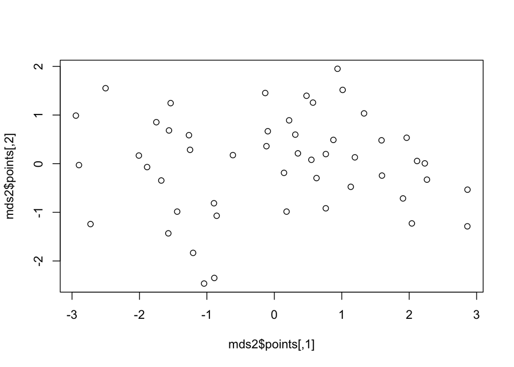

```r
plot(mds2$points)
```

We can then see some diagnostics

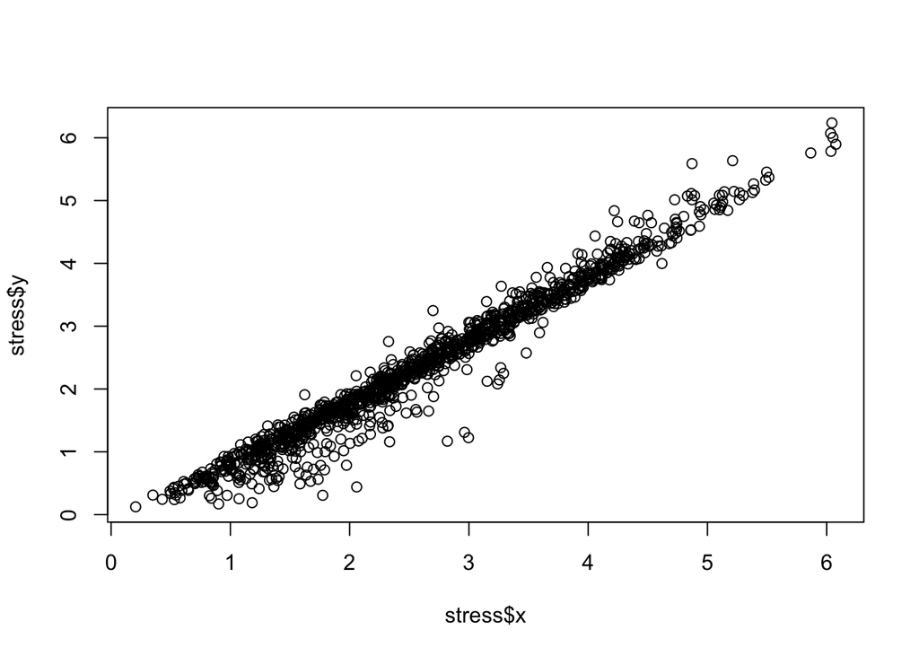

```r
stress <- Shepard(distances, mds2$points)
plot(stress)
```